Support Vector Machines (SVM) have first been developed by Vapnik and Lerner (1963) for classification tasks. First, based on the idea that there might be a hyperplane that perfectly separates two classes of the target in the linear case, the framework considers non-linearity and hence the non-existence of such such a hyperplane.

To overcome the issues that arise in the linear world, the feature space is enlarged using kernels to increase the dimension of the features which is an efficient computational approach.

Two popular kernels are:

- Polynomial kernel: $\mathcal{K}(x_i, x_i') = (1 + \sum_{j=1}^{p}x_{ij}x_{i'j})^d$  
  with $\mathcal{d}$ indicating the dimension of the polynomial and $\mathcal{p}$ denoting the number of features
- Radial kernel: $\mathcal{K}(x_i, x_i') = exp(-\gamma\sum_{j=1}^{p}(x_{ij}-x_{i'j})^2)$  
  with $\gamma$ denoting a hyperparameter to be tuned

As the kernels show, one only needs to compute the kernel function for all ${\mathcal N \choose 2}$ pairs of distinct ${\mathcal i, i'}$, rather than directly computing the values in the higher feature space.

The idea of SVM can also be transferred to the regression task. The optimization problem for Support Vector Regression (Vapnik 1995) takes the following form:

Finally, $C$ denotes a regularization parameter to be tuned. It indicates the weight to minimize the error. To sum up the idea of Support Vector Regression, in contrast to simple linear regression, an error tolerance is imposed to achieve regularization.

The optimization problem is then solved by constructing a Lagrange function. Moreover, it can be shown that the algorithm can be described by dot products between the data.

Additionally, the features are transformed using z-scores to obtain data with zero mean and a standard deviation of one:

*z-Score Normalization*: $z_i= \frac{x_i-\overline{x}}{\sigma}$

The following illustration might be useful to understand how the algorithm works:

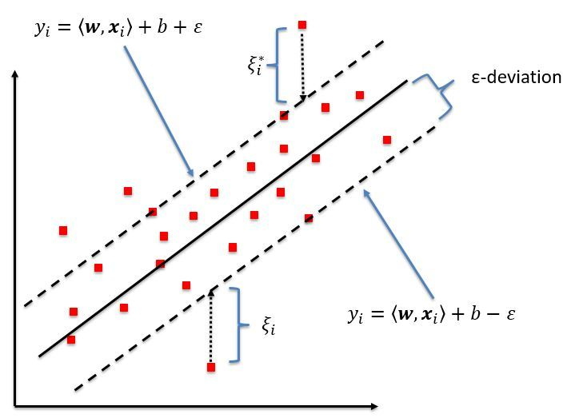

(Source: Kleynhans et al., 2017, p. 8)

*Sources*

- *Smola A. J., Schölkopf B., 2004, A tutorial on support vector regression*
- *James et al., 2017, An Introduction to Statistical Learning*
- *Klyenhans et al., 2017, Predicting Top-of-Atmosphere Thermal Radiance Using MERRA-2 Atmospheric Data with Deep Learning*
- *Crone et al., 2006, The Impact of Preprocessing on Support Vector Regression and Neural Networks in Time Series Prediction*